# Mastering the tidyverse

## 3.3 Beyond scatter plots

We can replace the `geom_point()` object with other types, for instance

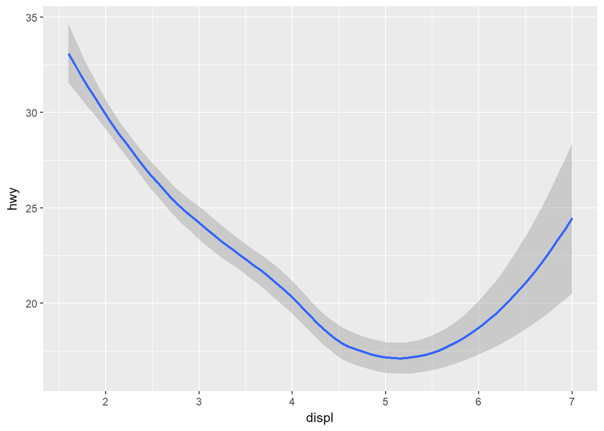

```r
ggplot(data=mpg)+
  geom_smooth(mapping = aes(x=displ, y=hwy))
```

Note however that not all aesthetics can be applied to all geometries. Now this is the part where `ggplot2` shines: You can put several layers together!

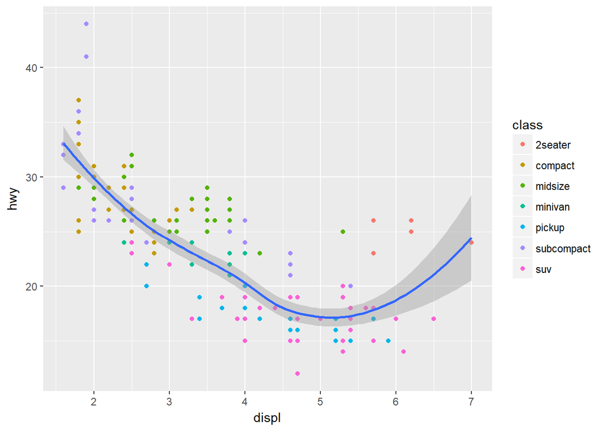

```r
ggplot(data=mpg)+
  geom_point(mapping = aes(x=displ, y=hwy, color=class))+
  geom_smooth(mapping = aes(x=displ, y=hwy))
```

Note that there’s a small detail with this: if you wanted to change the `y` variable, now you have to do changes in two layers, not only in one. To prevent that, you can specify the mapping on the `ggplot` function instead, so that it would be treated as a *global* mapping that applies to each layer.

For instance,

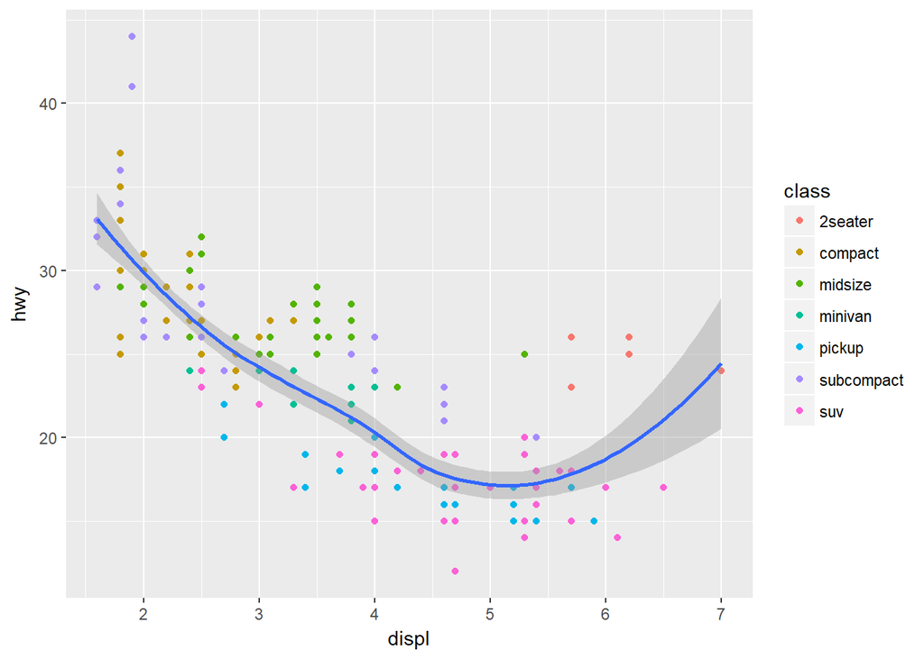

```r
ggplot(data=mpg, mapping = aes(x=displ, y=hwy))+
  geom_point(mapping=aes(color=class))+
  geom_smooth()
```

## 3.4 Statistical transformations

We can do groupings per category. For instance, let’s see how many cars do we have from each class:

```r
ggplot(data=mpg)+
  geom_bar(mapping = aes(x=class))
```

[output not shown]

Note that here we are not plotting the “raw” values that come in our data. Rather, we are doing aggregates **and then** plotting such values. Other graphs also calculate new values:

- Bar charts, histograms and other frequency polygons bin your data and then plot the number of elements that fall in each bin.
- Smoothers fit a model (`geom_smooth()` for instance).
- Boxplots/violinplots compute a special statistical plot.

Another way of doing the previous chart is using the `stat_count` function explicitly:

```r
ggplot(data=mpg)+
  stat_count(mapping = aes(x=class))
```

[output not shown]

Every `geom_` has a default `stat_` associated to it. Sometimes we need to override it:

```r
df <- tribble(
  ~class,         ~count,
   "2seater",        5,
 "compact",       47,
 "midsize",       41,
 "minivan",       11,
 "pickup",        33,
 "subcompact",    35,
 "suv",           62
)

ggplot(data = df) +
  geom_bar(mapping = aes(x = class, y = count), stat = "identity")
```

[output not shown]

When the data is already summarized, as in the example above, we need to override the default `stat_` that comes with `geom_bar`, namely, `stat_count`.

Sometimes you do not have the data aggregated, but you want to override the default count to get a proportion chart instead. In that case, you can do the following:

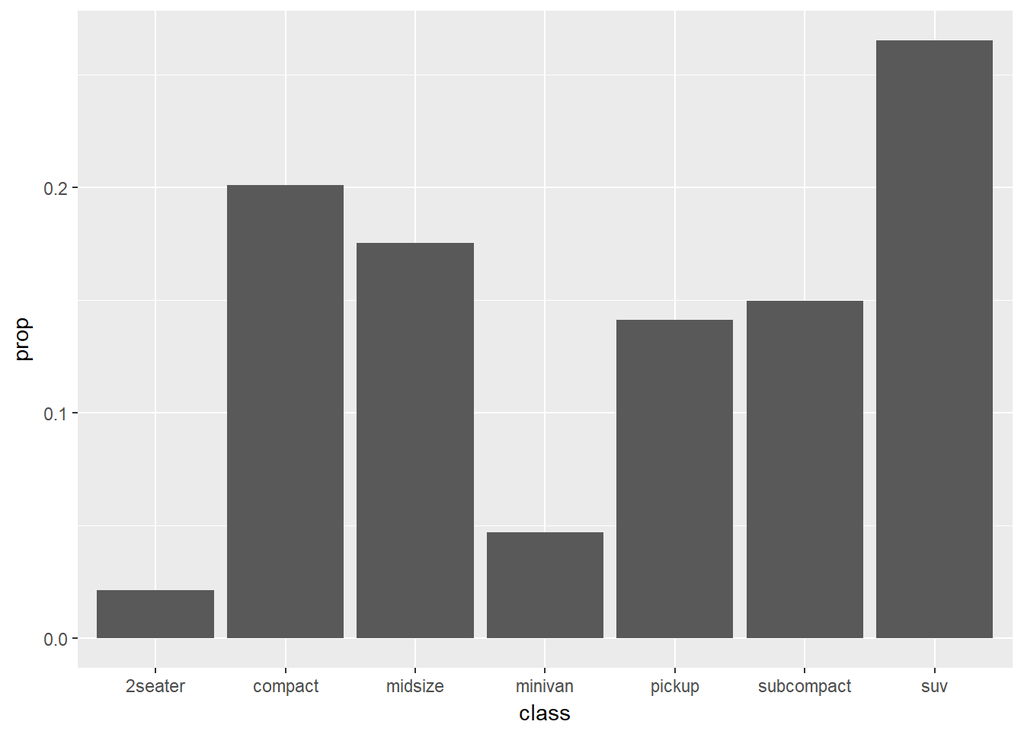

```r
ggplot(data=mpg)+
  geom_bar(mapping = aes(x=class, y=..prop.., group=1))
```

You can also look at the different variations within each class:

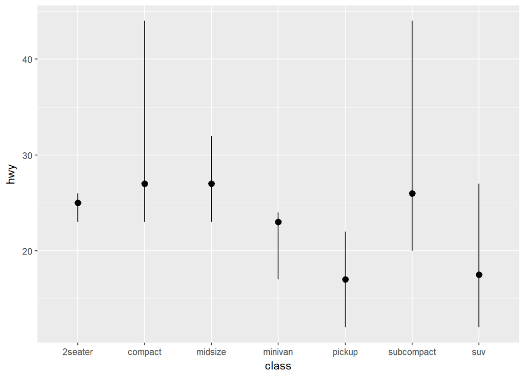

```r
ggplot(data = mpg)+
  stat_summary(
    mapping = aes(x=class, y=hwy),
    fun.ymin = min,
    fun.ymax = max,
    fun.y = median
  )
```

## 3.5 Position adjustments

We can color bar charts too, using either `color`:

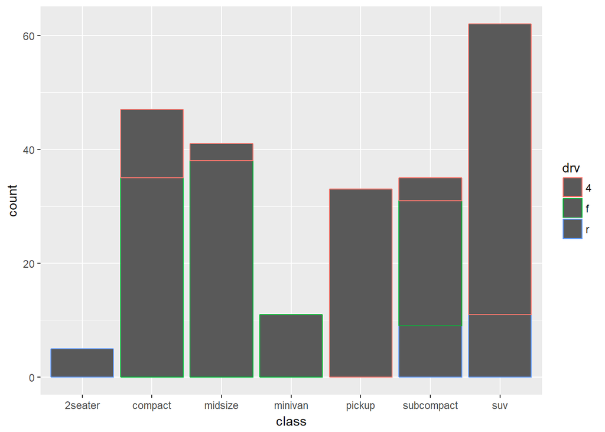

```r
ggplot(data = mpg)+
  geom_bar(mapping = aes(x=class, color=drv))
```

or `fill`:

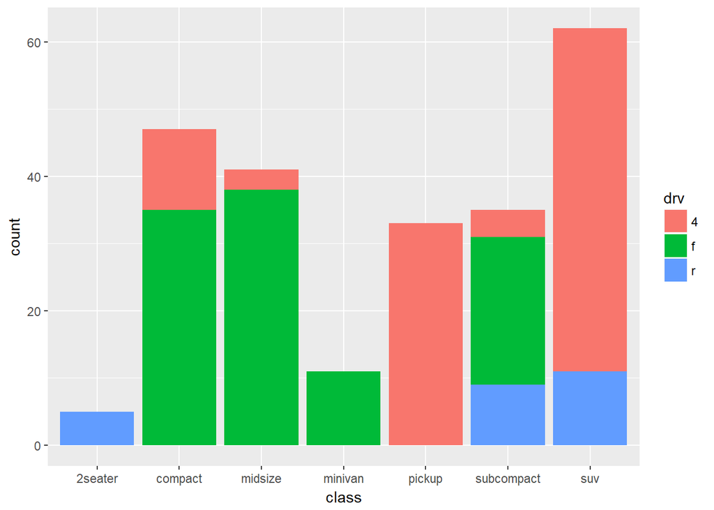

```r
ggplot(data = mpg)+
  geom_bar(mapping = aes(x=class, fill=drv))
```

The bars get in this case stacked. This is not great because the bars end up covering each other. We can make them visible by making the bars slightly transparent:

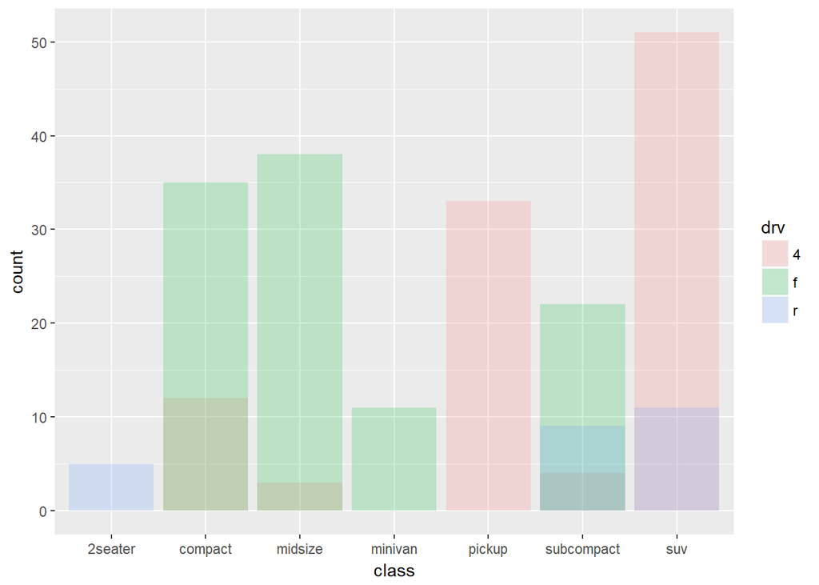

```r
ggplot(data = mpg)+
  geom_bar(mapping = aes(x=class, fill=drv), alpha=0.2, position = "identity")
```

Or, we can control the position:

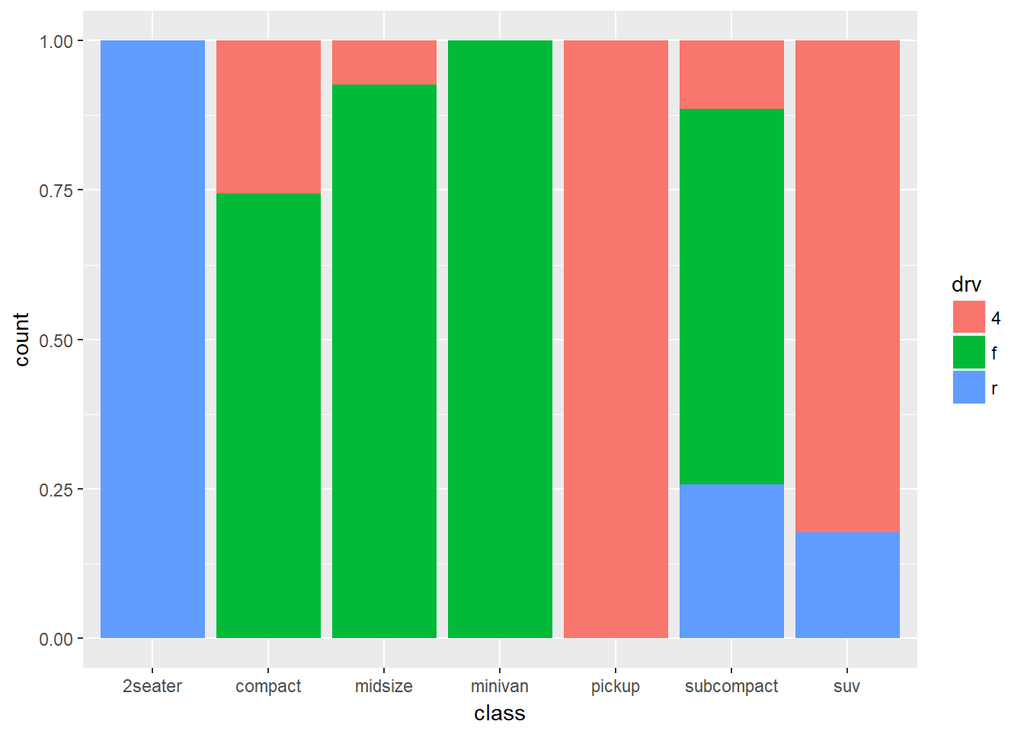

```r
ggplot(data = mpg)+
  geom_bar(mapping = aes(x=class, fill=drv), position = "fill")
```

We can also put them side by side:

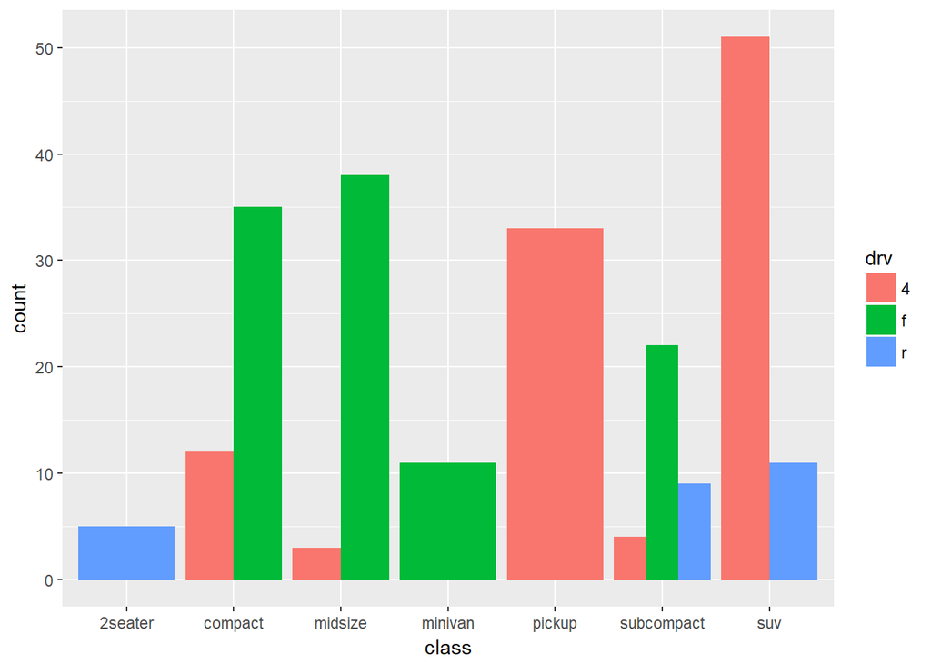

```r
ggplot(data = mpg)+
  geom_bar(mapping = aes(x=class, fill=drv), position = "dodge")
```

## 3.6 Exercises

Using the `diamonds` data set, reproduce the charts below. You might find it handy to get a copy of [RStudio’s Data Visualization Cheatsheet](https://www.rstudio.com/resources/cheatsheets/#ggplot2)

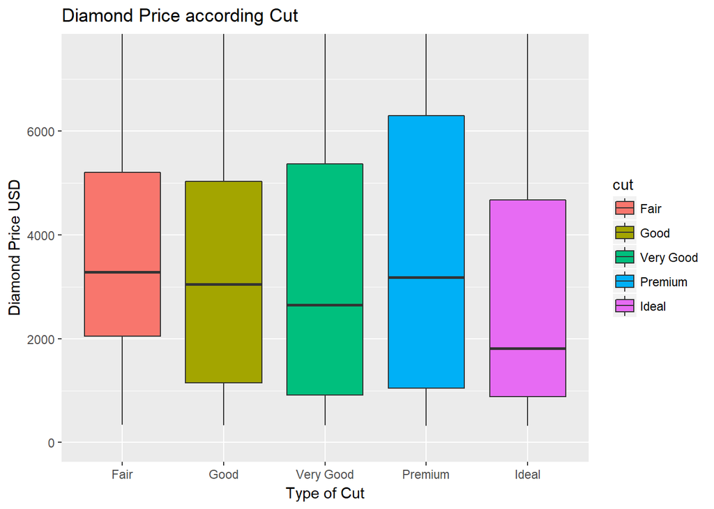

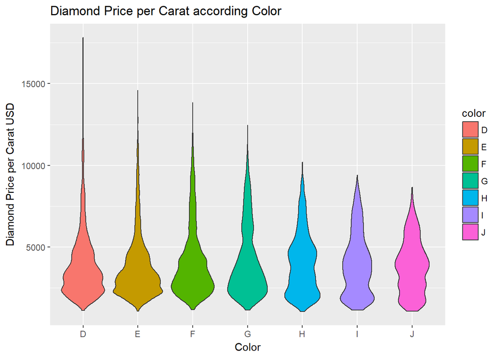

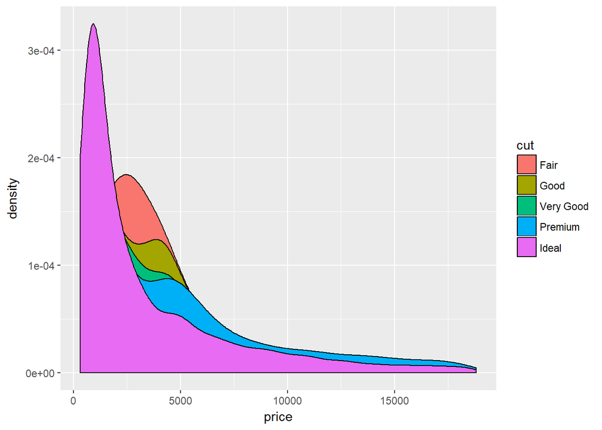

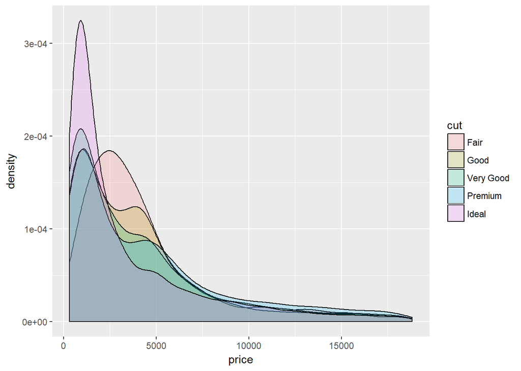

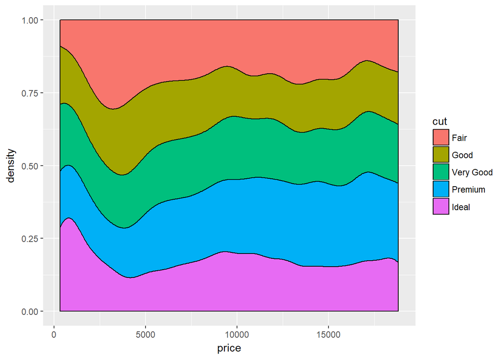

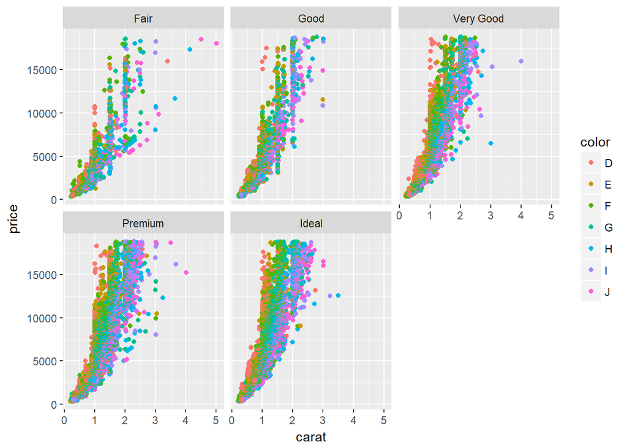

# 4 Strings and text with `stringr` and `tidytext`

The `stringr` package consists of functions for:

- Character manipulation in strings.
- Whitespace tools (add, remove and manipulate whitespace).
- Pattern matching functions, like regular expressions.

## 4.1 Introduction to stringr

We can get the length of a string:

```r
str_length("Machine learning")
```

```
## [1] 16
```

and get a part of it:

```r
s <- c("Machine learning")
str_sub(s, 1, 4)
```

```
## [1] "Mach"
```

We can also use this function to modify strings:

```r
str_sub(s, 8,8) <- "-"
s
```

```
## [1] "Machine-learning"
```

There are also functions to modify whitespace:

```r
short_long <- c("a short", "and a long string")
str_pad(short_long, 20)
```

```
## [1] "             a short" "   and a long string"
```

In this example, whitespace was added to have all strings of the same length.

To truncate strings:

```r
str_trunc(short_long, 8)
```

```
## [1] "a short"  "and a..."
```

Sometimes we do not want to add whitespace, but rather remove it:

```r
test <- c(" A lot of whitespace   ")
str_trim(test, "left")
```

```
## [1] "A lot of whitespace   "
```

and from the right:

```r
str_trim(test,"right")
```

```
## [1] " A lot of whitespace"
```

Sometimes it is useful to have the same case (upper/lowercase):

```r
str_to_upper(test)
```

```
## [1] " A LOT OF WHITESPACE   "
```

Similarly, `str_to_lower()` and `str_to_title()` can be used for lowercase and title (first letter of each word is capitalized).

### 4.1.1 Pattern matching

```r
fruits <- c("mango", "coconut", "grape", "pear")
str_view(fruits, "an")
```

[interactive chart not shown]

We can use `.` to match any character:

```r
str_view(fruits, 'pe.')
```

[interactive chart not shown]

The `.` has then a special use. This is a bit unfortunate, since we sometimes need to match it. We then have to use a special escape character, `\\.`, since `\` is also reserved. For instance:

```r
urls <- c("seznam.cz", "google.com", "facebook.com")
str_view(urls, "\\.")
```

[interactive chart not shown]

By default, regular expressions match any part of the string, but we can force it to anchor the beginning or end using the symbols `^` and `$`.

```r
str_view(fruits, '^m')
```

[interactive chart not shown]

Other separators include:

- `\d:` matches any digit.
- `\s:` matches any whitespace (e.g. space, tab, newline).
- `[abc]:` matches a, b, or c.
- `[a-z]`: matches lowercase letters.
- `[A-Z]`: matches uppercase letters.
- `[^abc]:` matches anything except a, b, or c.
- `?`: appears 0 or 1 times
- `+`: appears 1 or more times
- `*`: appears 0 or more times

We can also specify the number of matches:

- `{n}`: exactly n matches
- `{n,}`: n or more matches
- `{,m}`: at most m matches
- `{n,m}`: between n and m matches

For instance, let’s extract emails:

```r
text <- c("info@datastart.eu", "webmaster@cvut.cz", "bacon")
str_view(text, '[a-z]{4,10}@[a-z]{4,10}\\.[a-z]{2,}')
```

[interactive chart not shown]

This is of course a somewhat simplified version, since email addresses can be more complicated, see [here](http://emailregex.com/) for instance.

## 4.2 Practice!

Let’s use the `words`, `sentences` and `fruits` datasets included in `stringr`. Use the function `str_detect`.

- Find all words that start or end with x (in `words`, this and the next three exercises).
- Find all words that start with a vowel and end with a consonant.
- Are there any words that contain at least one of each vowel?
- What word has the highest proportion of vowels?
- What are the five most common words in `sentences`?
- How many fruits begin with a vowel?

# 5 Putting all together

We are ready to come back to the news data set:

```r
news<-read.csv("OnlineNewsPopularity.csv")
```

You will need to combine the tools from this tutorial to solve the following questions. You should do a visualization, whenever relevant.

- Plot the distribution of shares per weekday and per category (hint: facets).
- What article has the highest number of shares on each category?
- Extract the title of the articles from the url.
- Which brand is more mentioned? Apple or Samsung?